# Craft Beer

Alcohol Content and Bitterness Preference Analysis

October 16, 2018

Beer can be made using a range of ingredient to adjust the color, type and flavor profile. This analysis focuses on 2 measurements of beer composition, and some geographic details. The first measurement is Alcohol By Volume (ABV) which is a percentage that represents how much of a beer is alcohol versus other ingredients. The other measurment we will consider is International Business Units (IBU) whichis measured on a scale of 0 to 100 and describes the bitterness from hops in a beer. By law in the United States, the ABV must be listed on each beer to give customers an idea about how much alcohol is in each brew.

For this analysis, we have taken data 2410 craft beers and sales data from 558 US breweries to identify trends or regionality for preference. We use craft brewery data versus national brands as there is more product experimentation and product churn.

**There is a great amount of variablility in number of breweries by state. Colorado leads the country in breweries, followed by California, Michigan, Oregan and Texas.**

| State | Brew_Count |
| --- | --- |
| AK | 7 |
| AL | 3 |
| AR | 2 |
| AZ | 11 |
| CA | 39 |
| CO | 47 |
| CT | 8 |
| DC | 1 |
| DE | 2 |
| FL | 15 |

[output cut: 41 more lines]

**Data from Breweries and measurements including Beer Name, ABV, IBU and other attributes were pulled in to for some flexibility in analysis.**

```
##         Beer_Nm Beer_ID   ABV IBU                               Style
## 1  Get Together    2692 0.045  50                        American IPA
## 2 Maggie's Leap    2691 0.049  26                  Milk / Sweet Stout
## 3    Wall's End    2690 0.048  19                   English Brown Ale
## 4       Pumpion    2689 0.060  38                         Pumpkin Ale
## 5    Stronghold    2688 0.060  25                     American Porter
## 6   Parapet ESB    2687 0.056  47 Extra Special / Strong Bitter (ESB)
##   Ounces               Name        City State
## 1     16 NorthGate Brewing  Minneapolis    MN
## 2     16 NorthGate Brewing  Minneapolis    MN
## 3     16 NorthGate Brewing  Minneapolis    MN
## 4     16 NorthGate Brewing  Minneapolis    MN
## 5     16 NorthGate Brewing  Minneapolis    MN
## 6     16 NorthGate Brewing  Minneapolis    MN
```

```
##                        Beer_Nm Beer_ID   ABV IBU                   Style
## 2405             Pilsner Ukiah      98 0.055  NA         German Pilsener
## 2406  Heinnieweisse Weissebier      52 0.049  NA              Hefeweizen
## 2407           Snapperhead IPA      51 0.068  NA            American IPA
## 2408         Moo Thunder Stout      50 0.049  NA      Milk / Sweet Stout
## 2409         Porkslap Pale Ale      49 0.043  NA American Pale Ale (APA)
## 2410 Urban Wilderness Pale Ale      30 0.049  NA        English Pale Ale
##      Ounces                          Name          City State
## 2405     12         Ukiah Brewing Company         Ukiah    CA
## 2406     12       Butternuts Beer and Ale Garrattsville    NY
## 2407     12       Butternuts Beer and Ale Garrattsville    NY
## 2408     12       Butternuts Beer and Ale Garrattsville    NY
## 2409     12       Butternuts Beer and Ale Garrattsville    NY
## 2410     12 Sleeping Lady Brewing Company     Anchorage    AK
```

**There were incomplete data in the data sets as noted below. The field that was most commonly incomplete was IBU.**

```
## Beer_Nm Beer_ID     ABV     IBU   Style  Ounces    Name    City   State
##       0       0      62    1005       0       0       0       0       0
```

**For perspective, we looked at the median alchol content and bitterness unit for each state.**

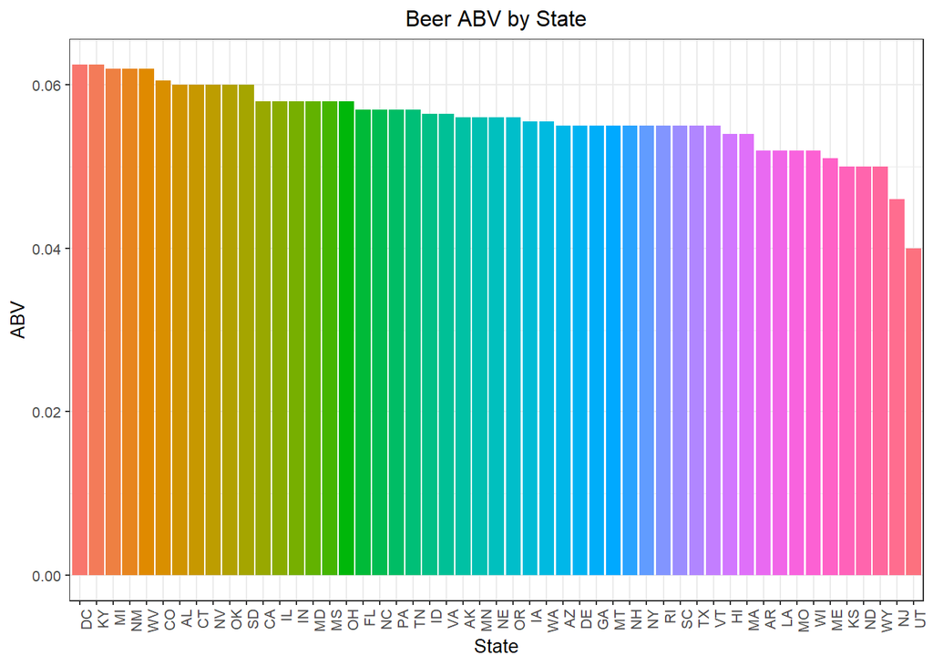

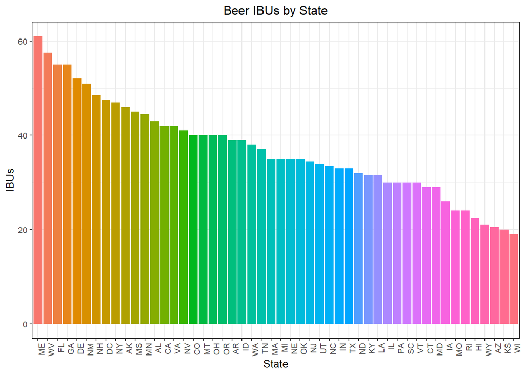

**Here is a closer look at the details for the highest values for ABV and IBU.**

```
##    State ABV_Pct
## 8     DC  0.0625
## 18    KY  0.0625
```

```
##    State IBUs
## 22    ME   61
```

**We wanted to share the range of the alcohol content and bitterness**

```
##    Min. 1st Qu.  Median    Mean 3rd Qu.    Max.
## 0.04000 0.05500 0.05600 0.05585 0.05800 0.06250
```

**We plotted bitterness and alcohol content to see if there was a relationship between the values, but the results were unremarkable."**

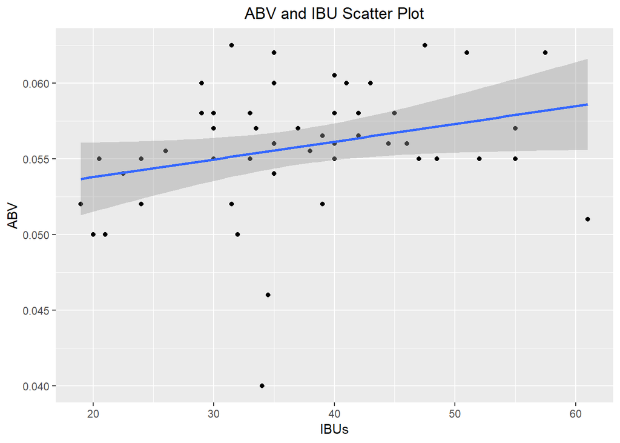

**The study showed a weak positive correlation (0.282) between ABV and IBUs using scatter plot and Pearson’s Product correlation formula.**

```
## [1] 0.2820948
```

**In Summary**

For further analysis, we recommend applying demographic information to the analysis to determine if different generational segments have preferences, and regionality of preference with the target generational segments.